# Assignment 2 - Data Wrangling, EDA, and Visualization

Author

Christian Navarro

## Due Date

This assignment is due by 11:59pm Pacific Time on Friday, October 10th, 2025.

# Learning Goals

- Practice getting familiar with an external dataset
- Reinforce good EDA practices
- Combine related datasets to answer questions
- Select appropriate data visualizations

# Dataset Description

For this assignment, we will be analyzing data from the `nycflights13` package, which provides information on all flights that left one of New York City’s three main airports in 2013. You can access this data by installing and loading the package, which provides five data frames: `airlines`, `airports`, `flights`, `planes`, and `weather`. These will not automatically populate in your Environment tab in RStudio, but if you want to see them there, you can assign each dataset to a variable of the same name (eg. `airlines <- airlines`).

The main data frame is `flights`, which contains information about every flight out of NYC. The 4 other data frames contain additional information, much of which would be highly redundant to include in the `flights` dataset (for example, information about JFK airport, or the full name of each airline rather than just the abbreviation).

# Questions

1. (7 points) Find the top 10 most popular destinations in the `flights` data. How many flights went to each?

```r
library(nycflights13)
library(dplyr)
top_dests <- flights %>%
  count(dest, sort = TRUE) %>%
  slice_max(n, n = 10)
print(top_dests)
```

```
# A tibble: 10 × 2
   dest      n
   <chr> <int>
 1 ORD   17283
 2 ATL   17215
 3 LAX   16174
 4 BOS   15508
 5 MCO   14082
 6 CLT   14064
 7 SFO   13331
 8 FLL   12055
 9 MIA   11728
10 DCA    9705
```

2. (10 points) Create two new categorical variables in `flights` based on the departure time (`dep_time`), and arrival time (`arr_time`). These new variables should have four categories: “early morning” for 12am to 6am, “morning” for 6am to 12pm, “afternoon” for 12pm to 6pm, and “evening” for 6pm to 12am. Show barplots of both of these new variables. What percentage of flights were “red eye” flights? We’ll define these as flights that depart in “afternoon” or “evening” and arrive in “early morning” or “morning.”

3.14868% flights were “red eye” flights

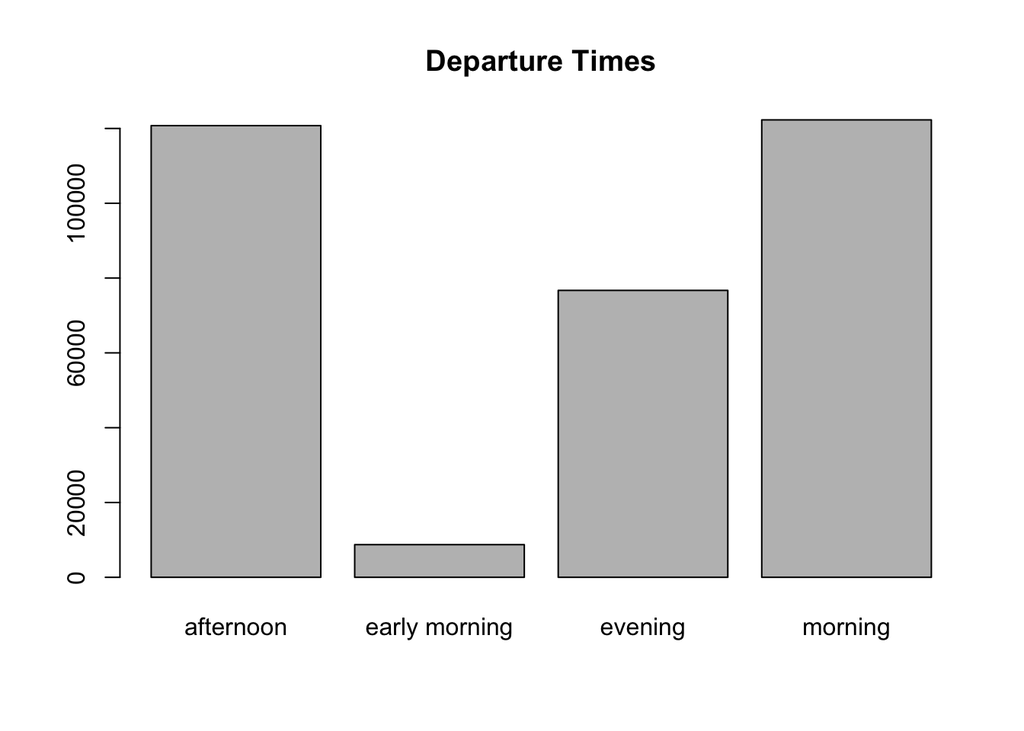

```r
flights <- flights %>%
  mutate(
    dep_time_cat = case_when(
      dep_time < 600 ~ "early morning",
      dep_time < 1200 ~ "morning",
      dep_time < 1800 ~ "afternoon",
      dep_time < 2400 ~ "evening",
      TRUE ~ NA_character_
    ),
    arr_time_cat = case_when(
      arr_time < 600 ~ "early morning",
      arr_time < 1200 ~ "morning",
      arr_time < 1800 ~ "afternoon",
      arr_time < 2400 ~ "evening",
      TRUE ~ NA_character_
    )
  )


barplot(table(flights$dep_time_cat), main = "Departure Times")
```

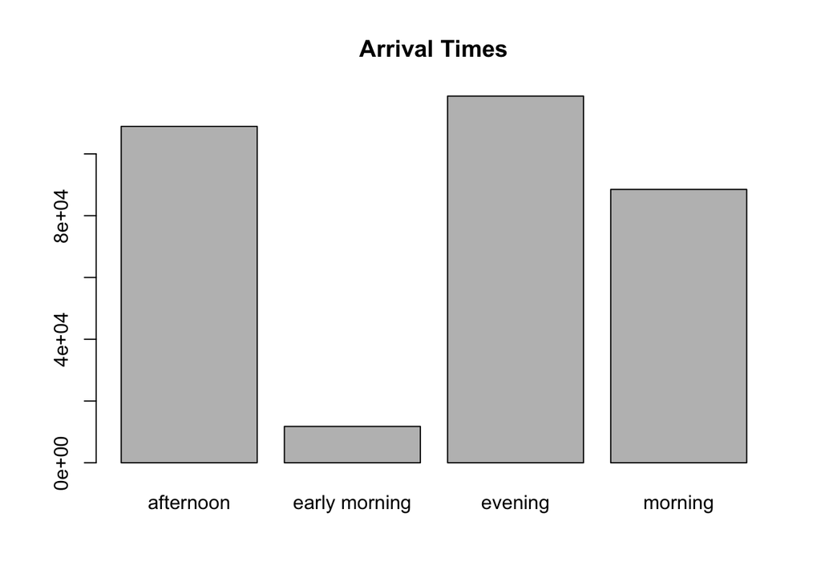

```r
barplot(table(flights$arr_time_cat), main = "Arrival Times")
```

```r
red_eye_flights <- flights %>%
  filter(dep_time_cat %in% c("afternoon", "evening"),
         arr_time_cat %in% c("early morning", "morning"))

red_eye_percent <- (nrow(red_eye_flights) / nrow(flights)) * 100
print(red_eye_percent)
```

```
[1] 3.14868
```

3. (7 points) Where there any planes that flew for multiple airlines? If so, how many were there and which airlines did they fly for?

```r
planes_multiple_airlines <- flights %>%
  select(tailnum, carrier) %>%
  distinct() %>%
  count(tailnum) %>%
  filter(n > 1)


num_planes_multiple <- nrow(planes_multiple_airlines)


airline_combinations <- flights %>%
  filter(tailnum %in% planes_multiple_airlines$tailnum) %>%
  select(tailnum, carrier) %>%
  distinct() %>%
  left_join(airlines, by = "carrier") %>%
  group_by(tailnum) %>%
  summarize(airlines = paste(name, collapse = ", "))

cat("Number of planes that flew for multiple airlines:", num_planes_multiple, "\n")
```

```
Number of planes that flew for multiple airlines: 18
```

```r
head(airline_combinations)
```

```
# A tibble: 6 × 2
  tailnum airlines
  <chr>   <chr>
1 N146PQ  Endeavor Air Inc., ExpressJet Airlines Inc.
2 N153PQ  Endeavor Air Inc., ExpressJet Airlines Inc.
3 N176PQ  Endeavor Air Inc., ExpressJet Airlines Inc.
4 N181PQ  Endeavor Air Inc., ExpressJet Airlines Inc.
5 N197PQ  Endeavor Air Inc., ExpressJet Airlines Inc.
6 N200PQ  Endeavor Air Inc., ExpressJet Airlines Inc.
```

The missing relationship is a “many-to-one” connection from `weather$origin` to `airports$faa`, where many weather records belong to one specific airport.

For the rest of this assignment, the primary question you should keep in mind is this:

> Which weather phenomena have the most impact on flight delays?

Don’t try to answer it now, but use this question to guide your exploratory data analysis.

5. (7 points) In order to address our primary question, we want to prepare a tidy dataset (a single data frame). This will consist of information from the `flights` and `weather` data. The `year`, `month`, `day`, `hour`, and `origin` variables from `weather` provide *almost* enough information to give each observation a unique value. Create a new variable in the weather dataset by pasting together those 5 variables, then determine how many duplicated values there are and explain why.

Now merge the `flights` data and the `weather` data so that each flight contains information about the weather at its **departure airport** at the time it was **scheduled** to take off. You’ll want to use the variables `time_hour` and `origin` in order to do this.

```r
weather <- weather %>%
  mutate(composite_key = paste(year, month, day, hour, origin))


num_duplicates <- weather %>%
  count(composite_key) %>%
  filter(n > 1) %>%
  nrow()

cat("Number of duplicated composite keys:", num_duplicates, "\n")
```

```
Number of duplicated composite keys: 3
```

```r
flights_weather <- flights %>%
  left_join(weather, by = c("origin", "time_hour"))
```

6. (20 points) On this merged dataset, perform steps 2-5 of the EDA checklist presented in class. Remember the context provided by our primary question above.

```r
dim(flights_weather)
```

```
[1] 336776     35
```

```r
nrow(flights_weather)
```

```
[1] 336776
```

```r
ncol(flights_weather)
```

```
[1] 35
```

```r
str(flights_weather)
```

```
tibble [336,776 × 35] (S3: tbl_df/tbl/data.frame)
 $ year.x        : int [1:336776] 2013 2013 2013 2013 2013 2013 2013 2013 2013 2013 ...
 $ month.x       : int [1:336776] 1 1 1 1 1 1 1 1 1 1 ...
 $ day.x         : int [1:336776] 1 1 1 1 1 1 1 1 1 1 ...
 $ dep_time      : int [1:336776] 517 533 542 544 554 554 555 557 557 558 ...
 $ sched_dep_time: int [1:336776] 515 529 540 545 600 558 600 600 600 600 ...
 $ dep_delay     : num [1:336776] 2 4 2 -1 -6 -4 -5 -3 -3 -2 ...
 $ arr_time      : int [1:336776] 830 850 923 1004 812 740 913 709 838 753 ...
 $ sched_arr_time: int [1:336776] 819 830 850 1022 837 728 854 723 846 745 ...
 $ arr_delay     : num [1:336776] 11 20 33 -18 -25 12 19 -14 -8 8 ...
 $ carrier       : chr [1:336776] "UA" "UA" "AA" "B6" ...
 $ flight        : int [1:336776] 1545 1714 1141 725 461 1696 507 5708 79 301 ...
 $ tailnum       : chr [1:336776] "N14228" "N24211" "N619AA" "N804JB" ...
 $ origin        : chr [1:336776] "EWR" "LGA" "JFK" "JFK" ...
 $ dest          : chr [1:336776] "IAH" "IAH" "MIA" "BQN" ...
```

[output cut: 21 more lines]

```r
summary(flights_weather)
```

```
     year.x        month.x           day.x          dep_time    sched_dep_time
 Min.   :2013   Min.   : 1.000   Min.   : 1.00   Min.   :   1   Min.   : 106
 1st Qu.:2013   1st Qu.: 4.000   1st Qu.: 8.00   1st Qu.: 907   1st Qu.: 906
 Median :2013   Median : 7.000   Median :16.00   Median :1401   Median :1359
 Mean   :2013   Mean   : 6.549   Mean   :15.71   Mean   :1349   Mean   :1344
 3rd Qu.:2013   3rd Qu.:10.000   3rd Qu.:23.00   3rd Qu.:1744   3rd Qu.:1729
 Max.   :2013   Max.   :12.000   Max.   :31.00   Max.   :2400   Max.   :2359
                                                 NA's   :8255
   dep_delay          arr_time    sched_arr_time   arr_delay
 Min.   : -43.00   Min.   :   1   Min.   :   1   Min.   : -86.000
 1st Qu.:  -5.00   1st Qu.:1104   1st Qu.:1124   1st Qu.: -17.000
 Median :  -2.00   Median :1535   Median :1556   Median :  -5.000
 Mean   :  12.64   Mean   :1502   Mean   :1536   Mean   :   6.895
 3rd Qu.:  11.00   3rd Qu.:1940   3rd Qu.:1945   3rd Qu.:  14.000
 Max.   :1301.00   Max.   :2400   Max.   :2359   Max.   :1272.000
 NA's   :8255      NA's   :8713                  NA's   :9430
   carrier              flight       tailnum             origin
 Length:336776      Min.   :   1   Length:336776      Length:336776
 Class :character   1st Qu.: 553   Class :character   Class :character
 Mode  :character   Median :1496   Mode  :character   Mode  :character
                    Mean   :1972
                    3rd Qu.:3465
                    Max.   :8500

     dest              air_time        distance        hour.x
 Length:336776      Min.   : 20.0   Min.   :  17   Min.   : 1.00
 Class :character   1st Qu.: 82.0   1st Qu.: 502   1st Qu.: 9.00
 Mode  :character   Median :129.0   Median : 872   Median :13.00
                    Mean   :150.7   Mean   :1040   Mean   :13.18
                    3rd Qu.:192.0   3rd Qu.:1389   3rd Qu.:17.00
                    Max.   :695.0   Max.   :4983   Max.   :23.00
                    NA's   :9430
     minute        time_hour                   dep_time_cat
 Min.   : 0.00   Min.   :2013-01-01 05:00:00   Length:336776
 1st Qu.: 8.00   1st Qu.:2013-04-04 13:00:00   Class :character
 Median :29.00   Median :2013-07-03 10:00:00   Mode  :character
 Mean   :26.23   Mean   :2013-07-03 05:22:54
 3rd Qu.:44.00   3rd Qu.:2013-10-01 07:00:00
 Max.   :59.00   Max.   :2013-12-31 23:00:00

```

[output cut: 17 more lines]

```
 Min.   :  0.0   Min.   : 0.000   Min.   :16.11    Min.   :0.00000
 1st Qu.:130.0   1st Qu.: 6.905   1st Qu.:20.71    1st Qu.:0.00000
 Median :220.0   Median :10.357   Median :24.17    Median :0.00000
 Mean   :201.5   Mean   :11.114   Mean   :25.25    Mean   :0.00456
 3rd Qu.:290.0   3rd Qu.:14.960   3rd Qu.:28.77    3rd Qu.:0.00000
 Max.   :360.0   Max.   :42.579   Max.   :66.75    Max.   :1.21000
 NA's   :9796    NA's   :1634     NA's   :256391   NA's   :1556
    pressure          visib        composite_key
 Min.   : 983.8   Min.   : 0.000   Length:336776
 1st Qu.:1012.7   1st Qu.:10.000   Class :character
 Median :1017.5   Median :10.000   Mode  :character
 Mean   :1017.8   Mean   : 9.256
 3rd Qu.:1022.8   3rd Qu.:10.000
 Max.   :1042.1   Max.   :10.000
 NA's   :38788    NA's   :1556
```

```r
head(flights_weather)
```

```
# A tibble: 6 × 35
  year.x month.x day.x dep_time sched_dep_time dep_delay arr_time sched_arr_time
   <int>   <int> <int>    <int>          <int>     <dbl>    <int>          <int>
1   2013       1     1      517            515         2      830            819
2   2013       1     1      533            529         4      850            830
3   2013       1     1      542            540         2      923            850
4   2013       1     1      544            545        -1     1004           1022
5   2013       1     1      554            600        -6      812            837
6   2013       1     1      554            558        -4      740            728
# ℹ 27 more variables: arr_delay <dbl>, carrier <chr>, flight <int>,
#   tailnum <chr>, origin <chr>, dest <chr>, air_time <dbl>, distance <dbl>,
#   hour.x <dbl>, minute <dbl>, time_hour <dttm>, dep_time_cat <chr>,
#   arr_time_cat <chr>, year.y <int>, month.y <int>, day.y <int>, hour.y <int>,
#   temp <dbl>, dewp <dbl>, humid <dbl>, wind_dir <dbl>, wind_speed <dbl>,
#   wind_gust <dbl>, precip <dbl>, pressure <dbl>, visib <dbl>,
#   composite_key <chr>
```

```r
tail(flights_weather)
```

```
# A tibble: 6 × 35
  year.x month.x day.x dep_time sched_dep_time dep_delay arr_time sched_arr_time
   <int>   <int> <int>    <int>          <int>     <dbl>    <int>          <int>
1   2013       9    30       NA           1842        NA       NA           2019
2   2013       9    30       NA           1455        NA       NA           1634
3   2013       9    30       NA           2200        NA       NA           2312
4   2013       9    30       NA           1210        NA       NA           1330
5   2013       9    30       NA           1159        NA       NA           1344
6   2013       9    30       NA            840        NA       NA           1020
# ℹ 27 more variables: arr_delay <dbl>, carrier <chr>, flight <int>,
#   tailnum <chr>, origin <chr>, dest <chr>, air_time <dbl>, distance <dbl>,
#   hour.x <dbl>, minute <dbl>, time_hour <dttm>, dep_time_cat <chr>,
#   arr_time_cat <chr>, year.y <int>, month.y <int>, day.y <int>, hour.y <int>,
#   temp <dbl>, dewp <dbl>, humid <dbl>, wind_dir <dbl>, wind_speed <dbl>,
#   wind_gust <dbl>, precip <dbl>, pressure <dbl>, visib <dbl>,
#   composite_key <chr>
```

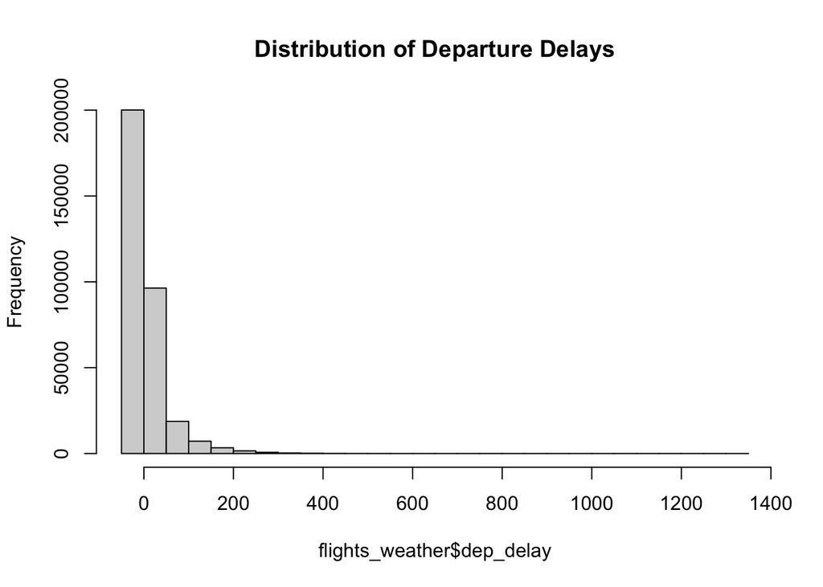

```r
hist(flights_weather$dep_delay, main = "Distribution of Departure Delays")
```

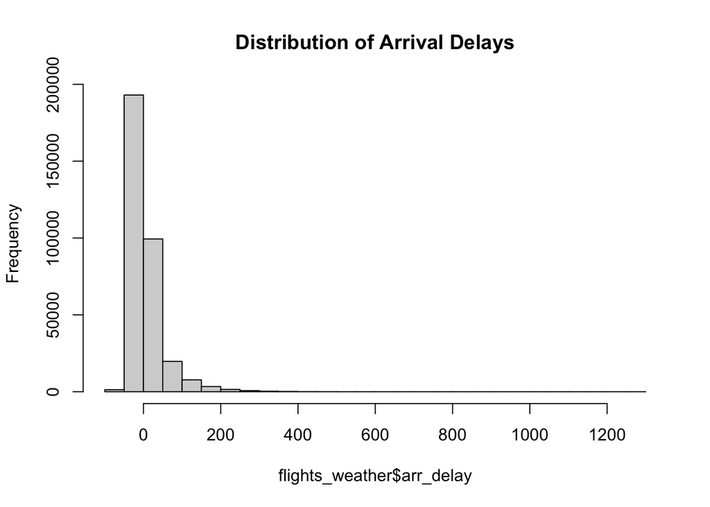

```r
hist(flights_weather$arr_delay, main = "Distribution of Arrival Delays")
```

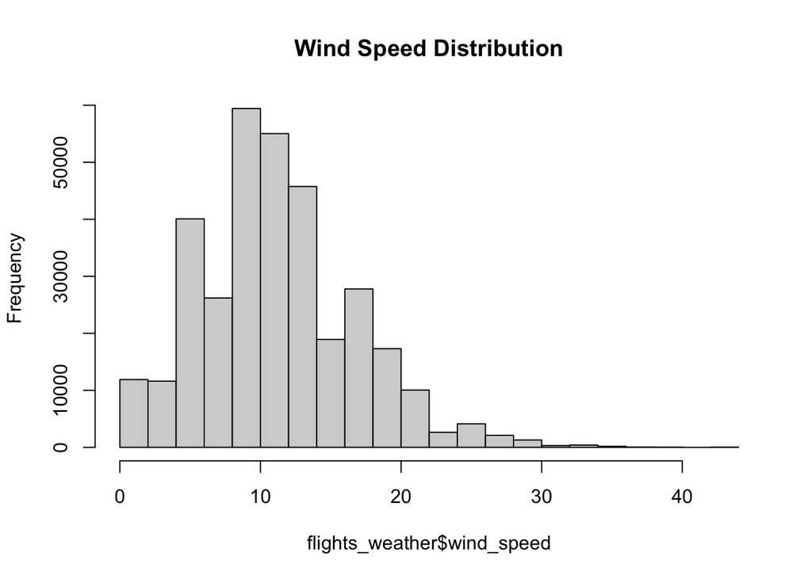

```r
hist(flights_weather$wind_speed, main = "Wind Speed Distribution")
```

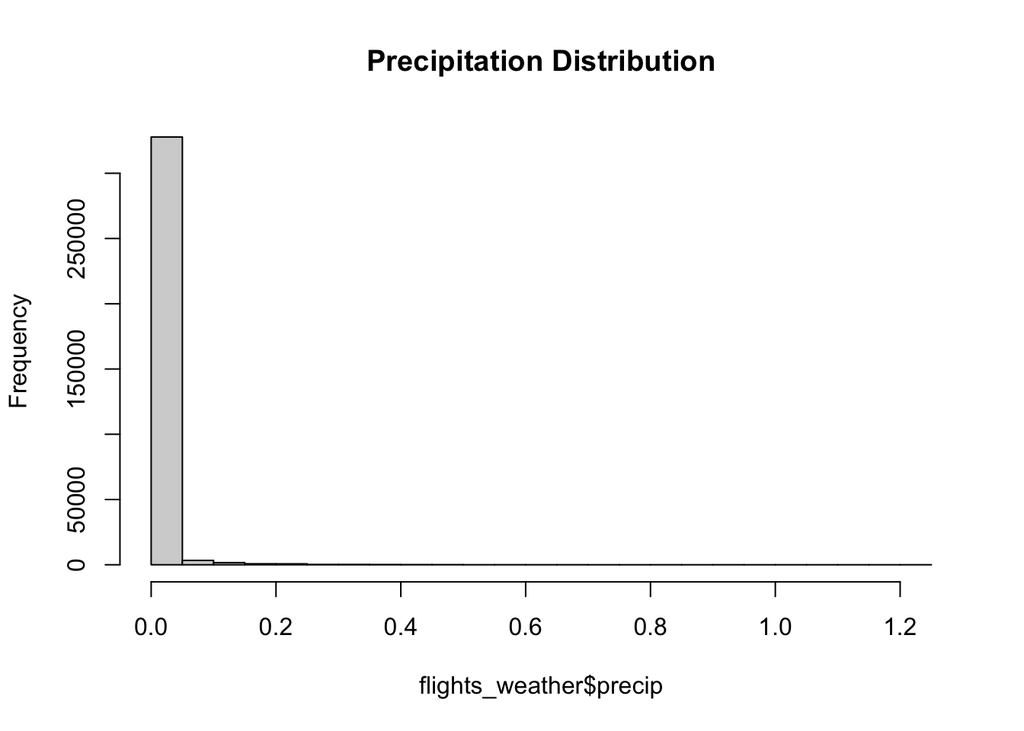

```r
hist(flights_weather$precip, main = "Precipitation Distribution")
```

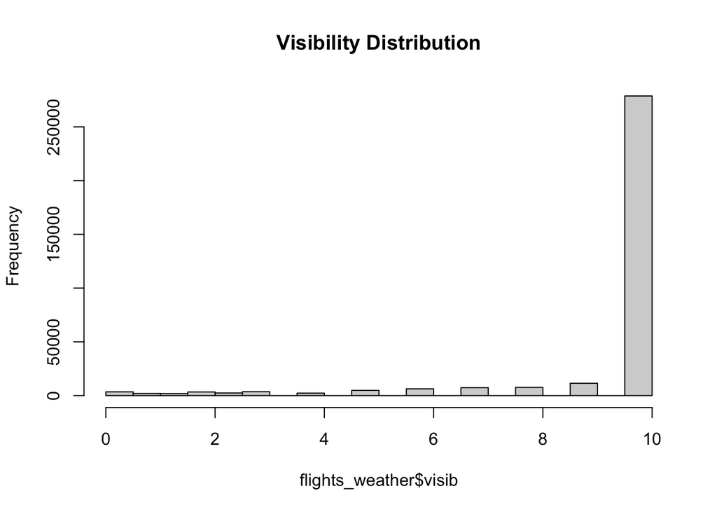

```r
hist(flights_weather$visib, main = "Visibility Distribution")
```

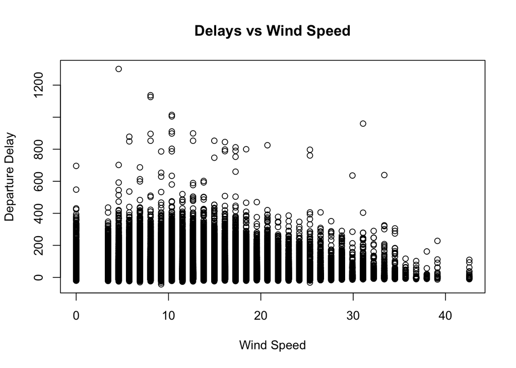

```r
plot(flights_weather$wind_speed, flights_weather$dep_delay,
     xlab = "Wind Speed", ylab = "Departure Delay", main = "Delays vs Wind Speed")
```

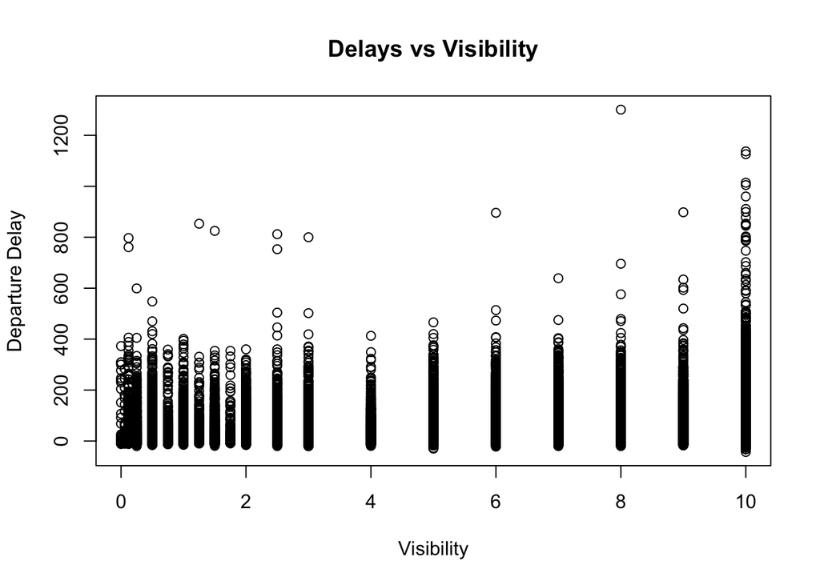

```r
plot(flights_weather$visib, flights_weather$dep_delay,
     xlab = "Visibility", ylab = "Departure Delay", main = "Delays vs Visibility")
```

7. (15 points) Calculate the average departure delay for each **day** (Hint: think about which variables you need in order to do this!). Which day had the worst average length of delay for departures? Now calculate the averages by **day** and **origin**. Which airport had the worst single day for delays and when was it? Now calculate the averages by **hour** and **origin**. Which airport had the worst single hour for delays (and when was it)?

```r
flights_weather <- flights_weather %>%
  mutate(
    year = lubridate::year(time_hour),
    month = lubridate::month(time_hour),
    day = lubridate::day(time_hour),
    hour = lubridate::hour(time_hour)
  )


daily_delays <- flights_weather %>%
  group_by(year, month, day) %>%
  summarize(mean_dep_delay = mean(dep_delay, na.rm = TRUE), .groups = "drop") %>%
  arrange(desc(mean_dep_delay))

worst_day <- daily_delays %>% slice_head(n = 1)
cat("Worst day for delays:", worst_day$month, "/", worst_day$day, "/", worst_day$year,
    "with average delay of", round(worst_day$mean_dep_delay, 1), "minutes\n")
```

```
Worst day for delays: 3 / 8 / 2013 with average delay of 83.5 minutes
```

```r
daily_origin_delays <- flights_weather %>%
  group_by(origin, year, month, day) %>%
  summarize(mean_dep_delay = mean(dep_delay, na.rm = TRUE), .groups = "drop") %>%
  arrange(desc(mean_dep_delay))

worst_day_origin <- daily_origin_delays %>% slice_head(n = 1)
cat("Worst single airport day: Airport", worst_day_origin$origin, "on",
    worst_day_origin$month, "/", worst_day_origin$day, "/", worst_day_origin$year,
    "with average delay of", round(worst_day_origin$mean_dep_delay, 1), "minutes\n")
```

```
Worst single airport day: Airport LGA on 3 / 8 / 2013 with average delay of 105.7 minutes
```

```r
hourly_origin_delays <- flights_weather %>%
  group_by(origin, year, month, day, hour) %>%
  summarize(mean_dep_delay = mean(dep_delay, na.rm = TRUE), .groups = "drop") %>%
  arrange(desc(mean_dep_delay))

worst_hour_origin <- hourly_origin_delays %>% slice_head(n = 1)
cat("Worst single airport hour: Airport", worst_hour_origin$origin, "at",
    worst_hour_origin$hour, ":00 on", worst_hour_origin$month, "/",
    worst_hour_origin$day, "/", worst_hour_origin$year, "with average delay of",
    round(worst_hour_origin$mean_dep_delay, 1), "minutes\n")
```

```
Worst single airport hour: Airport LGA at 21 :00 on 7 / 28 / 2013 with average delay of 279.7 minutes
```

8. (7 points) Compute the average delay by destination, then add that information to the `airports` data frame. Make a map showing the spatial distribution of delays (you can make it however you like, but we recommend using either `ggplot` or `leaflet`). Use the color of the points to display the average delay for each airport.

```r
dest_delays <- flights %>%
  group_by(dest) %>%
  summarize(mean_arr_delay = mean(arr_delay, na.rm = TRUE), .groups = "drop")


airports_with_delays <- airports %>%
  left_join(dest_delays, by = c("faa" = "dest")) %>%
  filter(!is.na(mean_arr_delay))


library(leaflet)

delay_pal <- colorNumeric(
  palette = c("blue", "white", "red"),
  domain = airports_with_delays$mean_arr_delay
)

leaflet(airports_with_delays) %>%
  addProviderTiles('CartoDB.Positron') %>%
  addCircles(
    lng = ~lon,
    lat = ~lat,
    color = ~delay_pal(mean_arr_delay),
    fillOpacity = 0.7,
    radius = 5000,
    popup = ~paste(name, ":", round(mean_arr_delay, 1), "min")
  ) %>%
  addLegend(
    "bottomleft",
    pal = delay_pal,
    values = ~mean_arr_delay,
    title = "Avg Delay (min)"
  )
```

[interactive chart not shown]

9. (20 points) Finally, create as many plots and summary statistics as needed to answer the primary question above.

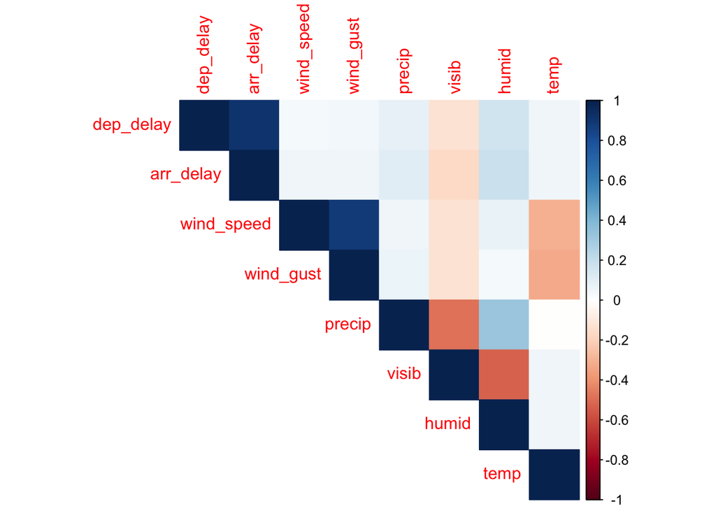

```r
# Primary Question: Which weather phenomena have the most impact on flight delays?

library(corrplot)
library(ggplot2)
weather_vars <- flights_weather %>%
  select(dep_delay, arr_delay, wind_speed, wind_gust, precip, visib, humid, temp) %>%
  na.omit()

cor_matrix <- cor(weather_vars)
corrplot(cor_matrix, method = "color", type = "upper")
```

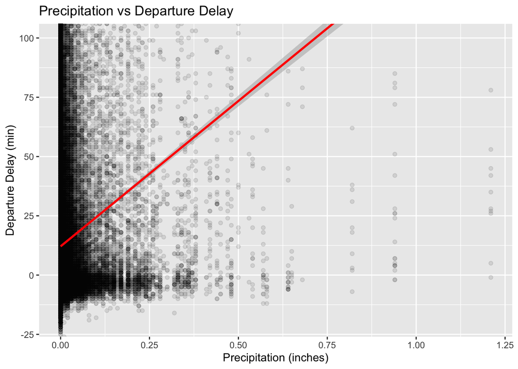

```r
ggplot(flights_weather, aes(x = precip, y = dep_delay)) +
  geom_point(alpha = 0.1) +
  geom_smooth(method = "lm", color = "red") +
  labs(title = "Precipitation vs Departure Delay",
       x = "Precipitation (inches)", y = "Departure Delay (min)") +
  coord_cartesian(ylim = c(-20, 100))
```

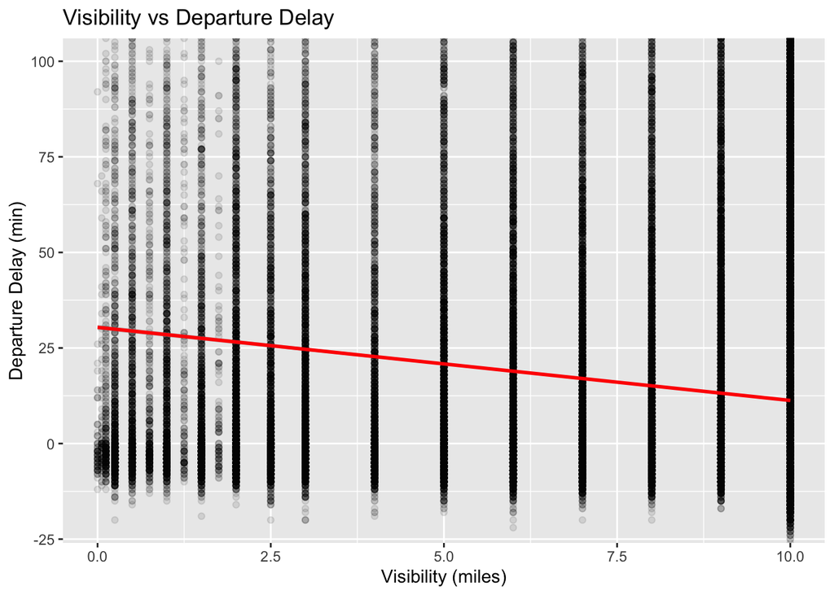

```r
ggplot(flights_weather, aes(x = visib, y = dep_delay)) +
  geom_point(alpha = 0.1) +
  geom_smooth(method = "lm", color = "red") +
  labs(title = "Visibility vs Departure Delay",
       x = "Visibility (miles)", y = "Departure Delay (min)") +
  coord_cartesian(ylim = c(-20, 100))
```

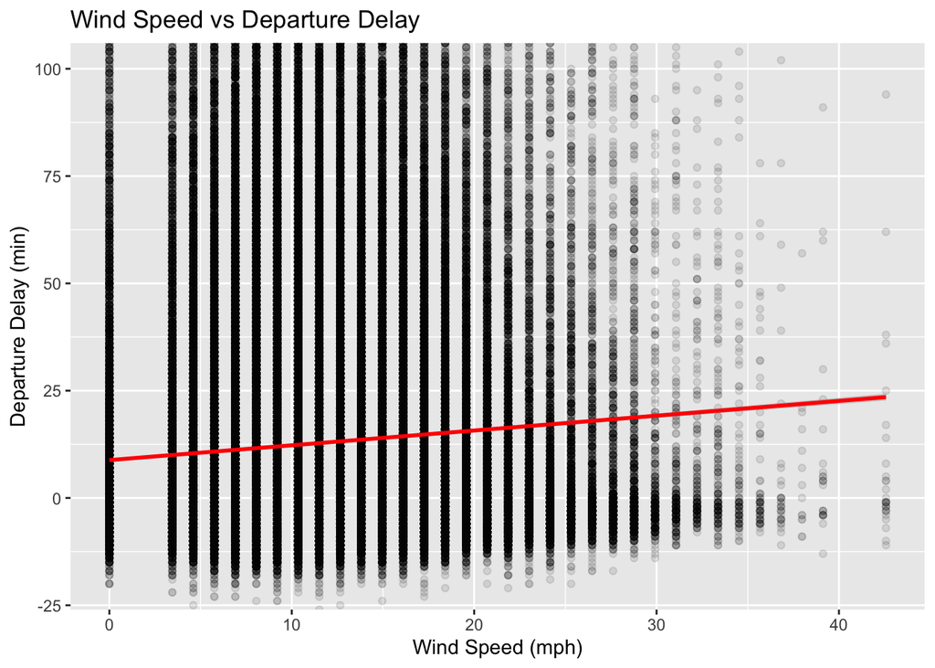

```r
ggplot(flights_weather, aes(x = wind_speed, y = dep_delay)) +
  geom_point(alpha = 0.1) +
  geom_smooth(method = "lm", color = "red") +
  labs(title = "Wind Speed vs Departure Delay",
       x = "Wind Speed (mph)", y = "Departure Delay (min)") +
  coord_cartesian(ylim = c(-20, 100))
```

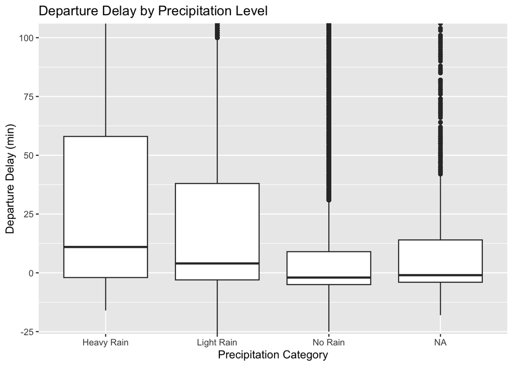

```r
flights_weather <- flights_weather %>%
  mutate(precip_cat = case_when(
    precip == 0 ~ "No Rain",
    precip > 0 & precip <= 0.1 ~ "Light Rain",
    precip > 0.1 ~ "Heavy Rain"
  ))

ggplot(flights_weather, aes(x = precip_cat, y = dep_delay)) +
  geom_boxplot() +
  coord_cartesian(ylim = c(-20, 100)) +
  labs(title = "Departure Delay by Precipitation Level",
       x = "Precipitation Category", y = "Departure Delay (min)")
```

```r
delay_summary <- flights_weather %>%
  group_by(precip_cat) %>%
  summarize(
    mean_dep_delay = mean(dep_delay, na.rm = TRUE),
    median_dep_delay = median(dep_delay, na.rm = TRUE),
    n_flights = n()
  )

print(delay_summary)
```

```
# A tibble: 4 × 4
  precip_cat mean_dep_delay median_dep_delay n_flights
  <chr>               <dbl>            <dbl>     <int>
1 Heavy Rain           40.9               11      4089
2 Light Rain           28.8                4     18913
3 No Rain              11.4               -2    312218
4 <NA>                 13.4               -1      1556
```

```r
library(broom)
weather_model <- lm(dep_delay ~ wind_speed + precip + visib + temp + humid,
                   data = flights_weather)
tidy_weather_model <- tidy(weather_model)
print(tidy_weather_model)
```

```
# A tibble: 6 × 5
  term        estimate std.error statistic   p.value
  <chr>          <dbl>     <dbl>     <dbl>     <dbl>
1 (Intercept)   -8.42    0.634       -13.3 2.65e- 40
2 wind_speed     0.570   0.0130       43.9 0
3 precip        71.4     2.49         28.7 4.98e-181
4 visib         -0.723   0.0434      -16.6 3.71e- 62
5 temp           0.160   0.00395      40.5 0
6 humid          0.203   0.00434      46.8 0
```

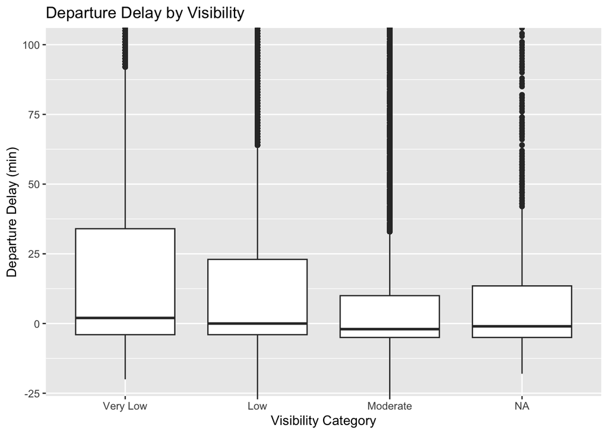

```r
flights_weather <- flights_weather %>%
  mutate(visib_cat = cut(visib,
                         breaks = c(0, 2, 6, 10, Inf),
                         labels = c("Very Low", "Low", "Moderate", "High")))

ggplot(flights_weather, aes(x = visib_cat, y = dep_delay)) +
  geom_boxplot() +
  coord_cartesian(ylim = c(-20, 100)) +
  labs(title = "Departure Delay by Visibility",
       x = "Visibility Category", y = "Departure Delay (min)")
```

```r
flights_weather <- flights_weather %>%
  mutate(wind_cat = ifelse(wind_speed > 15, "High Wind", "Normal Wind"))

combined_effect <- flights_weather %>%
  filter(!is.na(precip_cat) & !is.na(wind_cat)) %>%
  group_by(precip_cat, wind_cat) %>%
  summarize(mean_delay = mean(dep_delay, na.rm = TRUE), .groups = "drop")

print(combined_effect)
```

```
# A tibble: 6 × 3
  precip_cat wind_cat    mean_delay
  <chr>      <chr>            <dbl>
1 Heavy Rain High Wind         48.3
2 Heavy Rain Normal Wind       38.3
3 Light Rain High Wind         32.8
4 Light Rain Normal Wind       27.4
5 No Rain    High Wind         13.7
6 No Rain    Normal Wind       10.8
```

This homework has been adapted from the exercises presented in [Chapter 19](https://r4ds.hadley.nz/joins.html) of [R for Data Science (2e)](https://r4ds.hadley.nz/) by Wickham, Çentinkaya-Rundel, and Grolemund.